Datos públicos reales · Superintendencia Financiera de Colombia vía datos.gov.co · informe generado automáticamente con R

DIANA RODRÍGUEZ← Todos los bancos

INFORME MENSUAL · NOVIEMBRE 2026

# Banco Popular: colocación de crédito

$304,3 mil millones

desembolsado en noviembre 2026

-76,3 %

frente a octubre 2026

1,2 %

del mercado · puesto 12 de 29

17,31 %

tasa ponderada E.A. (mercado 19,64 %)

## Lectura del mes

- En noviembre 2026, **Banco Popular** desembolsó **$304,3 mil millones** en 12.175 créditos, una caída de 76,3 % frente a octubre 2026.
- Tiene el **1,2 %** de lo desembolsado por los bancos y ocupa el puesto 12 de 29. Desde enero 2026 su participación ganó 0,16 puntos porcentuales.
- Su principal línea es **Consumo**, con el 67,0 % de su monto; ahí tiene el 2,3 % del mercado.
- Es más barato que el mercado en **Consumo** (-3,49 pp) y **Comercial ordinario** (-4,13 pp).

La tasa total depende de la mezcla de productos: un banco con más consumo tendrá una tasa promedio más alta. Por eso la comparación justa es por tipo de crédito, en la segunda gráfica.

## Participación en el mercado, mes a mes

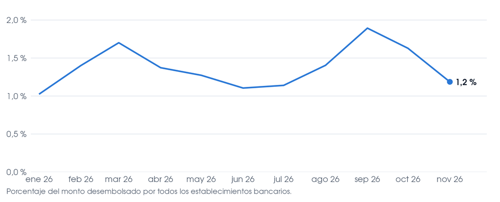

## Tasa por tipo de crédito: Banco Popular frente al mercado

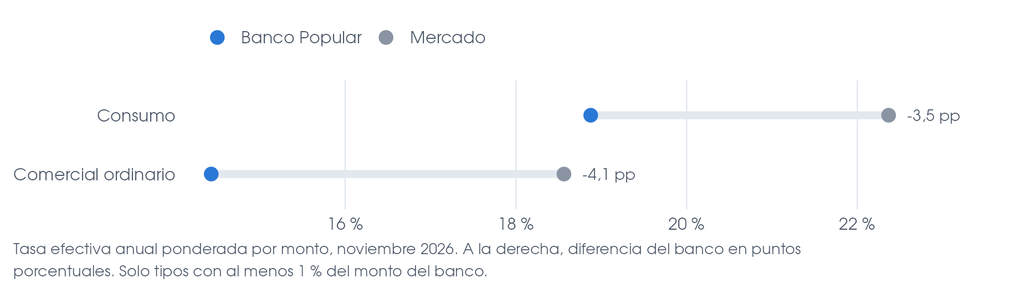

## En qué presta

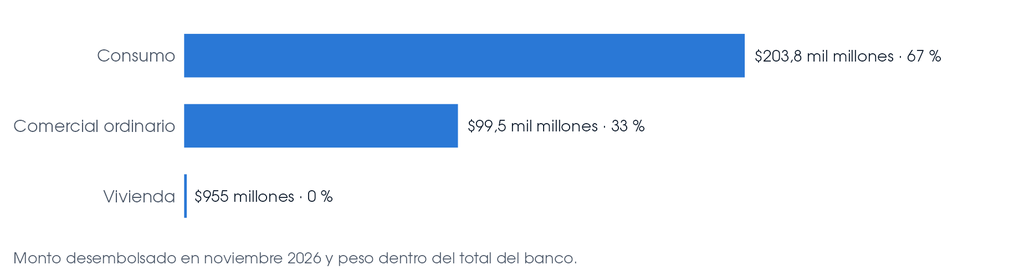

## Principales productos del mes

| Producto | Monto | Participación en el producto | Tasa banco | Tasa mercado | Diferencia |
| --- | --- | --- | --- | --- | --- |
| Libranza otros | $160,7 mil millones | 18,5 % | 17,46 % | 18,43 % | -0,97 pp |
| Empresarial en pesos | $77,8 mil millones | 2,7 % | 14,51 % | 16,32 % | -1,82 pp |
| Tarjeta de crédito para ingresos superiores a 2 smmlv | $41,2 mil millones | 0,90 % | 26,81 % | 22,13 % | +4,68 pp |
| Comerciales con recursos provenientes de redescuento | $18,3 mil millones | 5,5 % | 12,86 % | 14,52 % | -1,66 pp |
| Leasing financiero - financiación inmuebles diferente de habitacional | $2,2 mil millones | 2,3 % | 17,08 % | 16,55 % | +0,53 pp |
| Tarjeta de crédito para ingresos hasta 2 smmlv | $1,8 mil millones | 0,19 % | 27,23 % | 23,78 % | +3,45 pp |
| Sobregiro en cuenta corriente persona jurídica o persona natural | $1,2 mil millones | 0,03 % | 28,04 % | 23,55 % | +4,48 pp |
| Vivienda empleados | $955 millones | 3,0 % | 5,20 % | 7,50 % | -2,30 pp |

## Cómo se hizo

Este informe se escribe solo. Un script en R lee los datos que el Monitor de mercado descarga de la Superintendencia Financiera, calcula los indicadores y redacta el texto con reglas: por ejemplo, señala un tipo de crédito como «más caro que el mercado» cuando la diferencia supera 2 puntos y pesa al menos el 5 % del banco. Con R Markdown se genera un informe por cada banco, con los mismos parámetros. GitHub Actions lo vuelve a producir cada vez que llegan datos nuevos.

Montos en pesos corrientes. Tasas efectivas anuales ponderadas por el monto desembolsado. Cifras de enero 2026 a noviembre 2026; el último mes puede ajustarse cuando la Superintendencia publique correcciones. [Ver el código en GitHub →](https://github.com/dsrodriguezq/dsrodriguezq.github.io/tree/main/proyectos/informe-bancos-r)